# Análise de Dados

28/02/2021

## Horário:

- 19 de Março das 9 às 13
- 20 de Março das 10 às 12

## Material desta apresentação

https://github.com/rcm/AnaliseDados

## Aulas e avaliação

- Metodologia TBL
- Trabalho em grupo
- Avaliação de pares
  - *intra*-grupo
  - *extra*-grupo
- Projeto
  - Escolher um dataset
  - Analisar o dataset
  - Produzir uma apresentação com a análise do dataset
  - Colocar no [padlet](https://padlet.com/ruicmendes/AnaliseDados)

## Sugestões de datasets

- [Eurostat](https://cran.r-project.org/web/packages/eurostat/index.html)
- [Covid-19](https://github.com/CSSEGISandData)
- [FluMOMO](https://www.euromomo.eu/how-it-works/flumomo/)
- [UCI Machine Learning Repository](https://archive.ics.uci.edu/ml/index.php)

## Ir buscar o R

1. Ir a https://www.r-project.org/
2. Escolher o mirror
3. Escolher o sistema operativo
4. Ir buscar o base
5. Instalar
6. Ir buscar o RStudio

## Como instalar pacotes no R

- Configurar o mirror (Packages -> Set mirror)
- Usar o comando *install.packages* ou
- Usar a opção do R (Packages -> Install packages)

## Cheat sheets

Eis o URL: https://rstudio.com/resources/cheatsheets/

- Data Import Cheatsheet
- Data Transformation Cheatsheet
- Data Visualization Cheatsheet
- Apply Functions Cheatsheet
- R Markdown Cheatsheet
- RStudio IDE Cheatsheet

## Pacotes utilizados nesta apresentação

- tidyverse
- broom
- factoextra

## Funções para analisar dados

- head
- summary
- count
- select
- filter
- group_by
- mutate
- summarise

## Tidyverse

Temos que importar o módulo *Tidyverse*

```r
library(tidyverse)
```

- Importa bastantes pacotes
- Possui muitas funções interessantes para a análise de dados

## Dataset utilizado neste exemplo

```r
mpg
```

```
# A tibble: 234 x 11
   manufacturer model    displ  year   cyl trans   drv     cty   hwy fl    class
   <chr>        <chr>    <dbl> <int> <int> <chr>   <chr> <int> <int> <chr> <chr>
 1 audi         a4         1.8  1999     4 auto(l~ f        18    29 p     comp~
 2 audi         a4         1.8  1999     4 manual~ f        21    29 p     comp~
 3 audi         a4         2    2008     4 manual~ f        20    31 p     comp~
 4 audi         a4         2    2008     4 auto(a~ f        21    30 p     comp~
 5 audi         a4         2.8  1999     6 auto(l~ f        16    26 p     comp~
 6 audi         a4         2.8  1999     6 manual~ f        18    26 p     comp~
 7 audi         a4         3.1  2008     6 auto(a~ f        18    27 p     comp~
 8 audi         a4 quat~   1.8  1999     4 manual~ 4        18    26 p     comp~
 9 audi         a4 quat~   1.8  1999     4 auto(l~ 4        16    25 p     comp~
10 audi         a4 quat~   2    2008     4 manual~ 4        20    28 p     comp~
# ... with 224 more rows
```

## Conceito de pipeline

- Utiliza o operador %>%
- Redireciona o resultado de um comando para o primeiro argumento do comando seguinte

```r
x = 2
f = function(x, y) x + y
x %>% f(7)
```

```
[1] 9
```

## Que atributos tem o dataset?

```r
mpg %>% names
```

```
 [1] "manufacturer" "model"        "displ"        "year"         "cyl"
 [6] "trans"        "drv"          "cty"          "hwy"          "fl"
[11] "class"
```

## Que tipos de transmissão há?

```r
mpg %>% count(trans)
```

```
# A tibble: 10 x 2
   trans          n
 * <chr>      <int>
 1 auto(av)       5
 2 auto(l3)       2
 3 auto(l4)      83
 4 auto(l5)      39
 5 auto(l6)       6
 6 auto(s4)       3
 7 auto(s5)       3
 8 auto(s6)      16
 9 manual(m5)    58
10 manual(m6)    19
```

## Que tipos de transmissão há?

```r
knitr::kable(mpg %>% count(trans) %>% head)
```

| trans | n |
| --- | --- |
| auto(av) | 5 |
| auto(l3) | 2 |
| auto(l4) | 83 |
| auto(l5) | 39 |
| auto(l6) | 6 |
| auto(s4) | 3 |

## Que tipos de transmissão há?

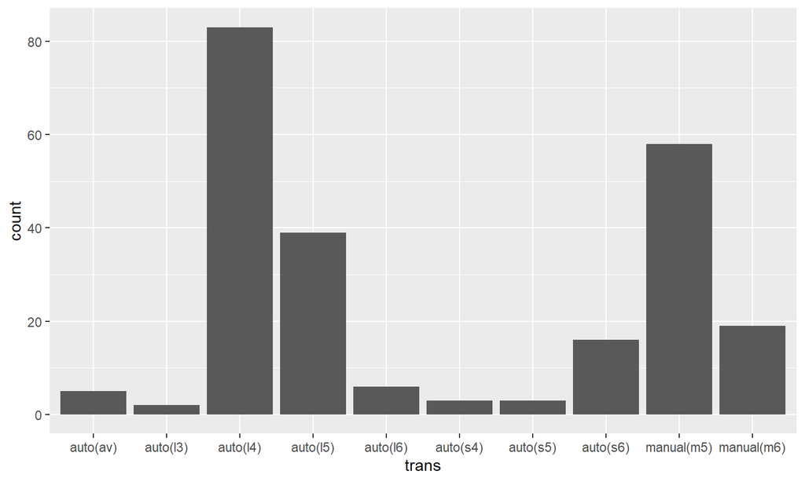

```r
mpg %>% ggplot(aes(trans)) + geom_bar()
```

## Média na cidade

```r
mpg %>% count(cut_width(cty, 5))
```

```
# A tibble: 6 x 2
  `cut_width(cty, 5)`     n
* <fct>               <int>
1 [7.5,12.5]             33
2 (12.5,17.5]            99
3 (17.5,22.5]            84
4 (22.5,27.5]            13
5 (27.5,32.5]             3
6 (32.5,37.5]             2
```

## Média na cidade

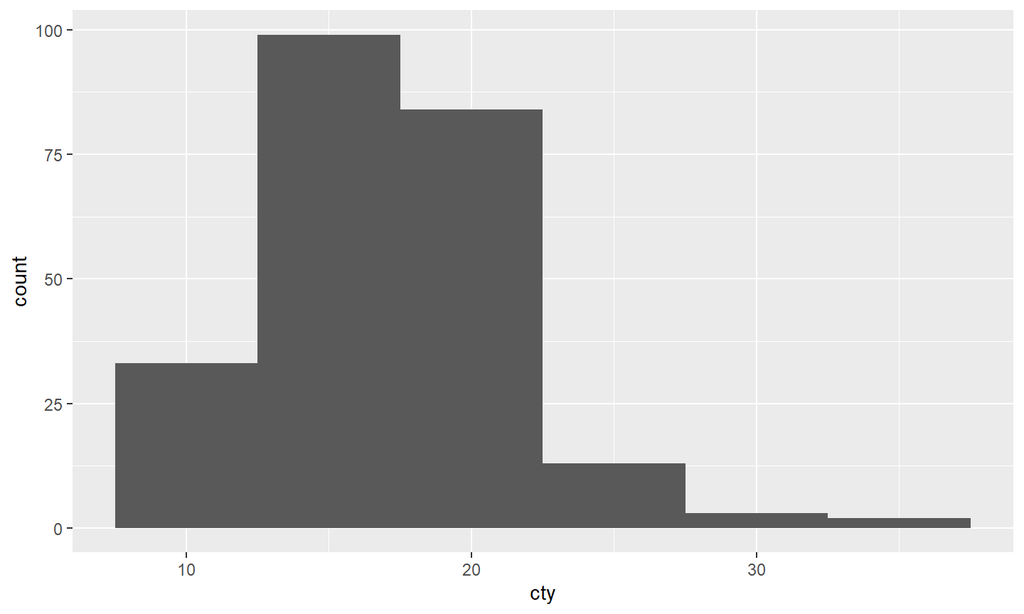

```r
mpg %>% ggplot + geom_histogram(mapping = aes(cty), binwidth = 5)
```

## Média na cidade consoante o nº de cilindros

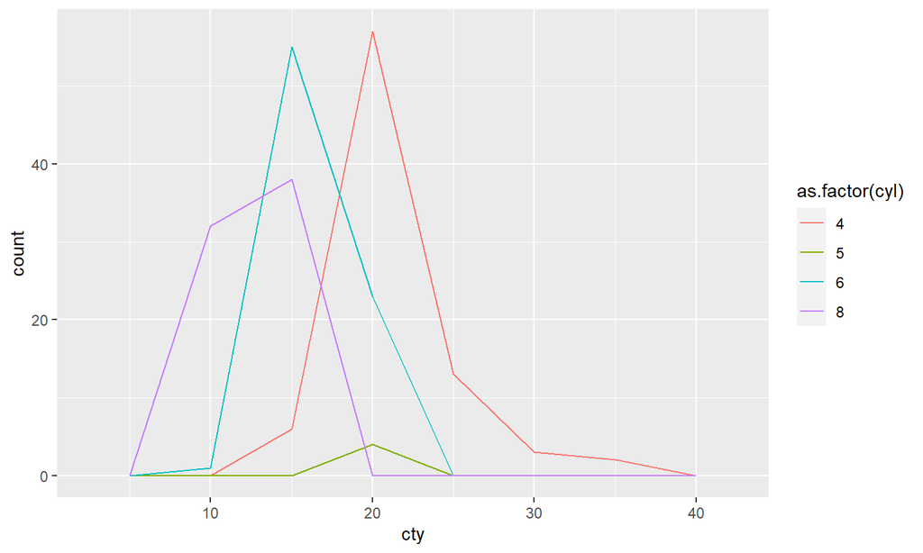

```r
mpg %>% ggplot(aes(x = cty, colour = as.factor(cyl))) + geom_freqpoly(binwidth=5)
```

## Média na cidade consoante o nº de cilindros

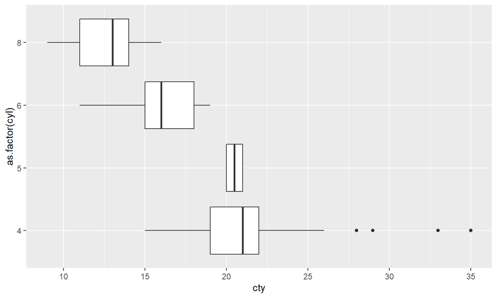

```r
mpg %>% ggplot(aes(x = cty, y = as.factor(cyl))) + geom_boxplot()
```

## Selecionar atributos

```r
mpg %>% select(year, cyl, cty, hwy, drv, fl)
```

```
# A tibble: 234 x 6
    year   cyl   cty   hwy drv   fl
   <int> <int> <int> <int> <chr> <chr>
 1  1999     4    18    29 f     p
 2  1999     4    21    29 f     p
 3  2008     4    20    31 f     p
 4  2008     4    21    30 f     p
 5  1999     6    16    26 f     p
 6  1999     6    18    26 f     p
 7  2008     6    18    27 f     p
 8  1999     4    18    26 4     p
 9  1999     4    16    25 4     p
10  2008     4    20    28 4     p
# ... with 224 more rows
```

## Selecionar linhas e atributos

```r
mpg %>% select(year, cyl, cty, hwy, drv, fl) %>% filter(cyl == 6)
```

```
# A tibble: 79 x 6
    year   cyl   cty   hwy drv   fl
   <int> <int> <int> <int> <chr> <chr>
 1  1999     6    16    26 f     p
 2  1999     6    18    26 f     p
 3  2008     6    18    27 f     p
 4  1999     6    15    25 4     p
 5  1999     6    17    25 4     p
 6  2008     6    17    25 4     p
 7  2008     6    15    25 4     p
 8  1999     6    15    24 4     p
 9  2008     6    17    25 4     p
10  1999     6    18    26 f     r
# ... with 69 more rows
```

## Selecionar linhas e atributos e ordenar

```r
mpg %>% select(year, cyl, cty, hwy, drv, fl) %>% filter(cyl == 6) %>%
  arrange(cty)
```

```
# A tibble: 79 x 6
    year   cyl   cty   hwy drv   fl
   <int> <int> <int> <int> <chr> <chr>
 1  2008     6    11    17 f     e
 2  1999     6    13    17 4     r
 3  1999     6    13    17 4     r
 4  2008     6    13    19 4     r
 5  2008     6    13    19 4     r
 6  2008     6    14    18 4     r
 7  1999     6    14    17 4     r
 8  1999     6    14    17 4     r
 9  1999     6    14    17 4     r
10  1999     6    14    17 4     r
# ... with 69 more rows
```

## Agrupamentos

Autonomia por tipo de combustível e cilindrada na auto-estrada

```r
mpg %>% group_by(fl, cyl) %>%
  summarize(media = mean(hwy), contagem = n(), .groups = "keep")
```

```
# A tibble: 13 x 4
# Groups:   fl, cyl [13]
   fl      cyl media contagem
   <chr> <int> <dbl>    <int>
 1 c         4  36          1
 2 d         4  43          3
 3 d         6  22          1
 4 d         8  17          1
 5 e         6  17          1
 6 e         8  12.7        7
 7 p         4  27.8       22
 8 p         6  25.3       17
 9 p         8  20.8       13
10 r         4  28.3       55
11 r         5  28.8        4
12 r         6  22.2       60
13 r         8  17.5       49
```

## COVID em Portugal

```
url = "https://raw.githubusercontent.com/CSSEGISandData/COVID-19/master/csse_covid_19_data/csse_covid_19_time_series/time_series_covid19_confirmed_global.csv"
read_csv(url) %>% filter(`Country/Region` == "Portugal") %>%
  pivot_longer(matches("\\d+/\\d+/\\d+"), values_to = "confirmados") %>%
  mutate(across(name, ~parse_datetime(.x, "%m/%d/%y"))) %>%
  ggplot(aes(x = name, y = confirmados)) + geom_line() + labs(x = "Data")
```

## COVID em Portugal

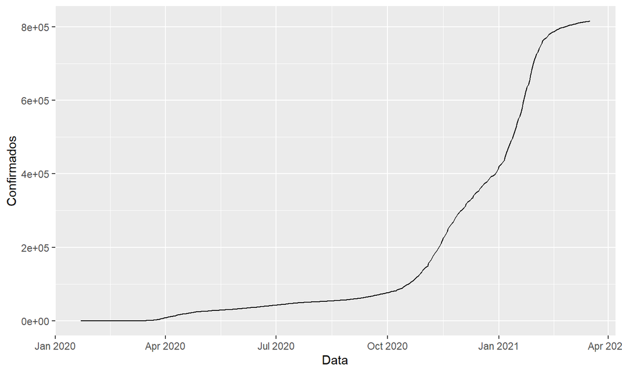

## COVID em Portugal

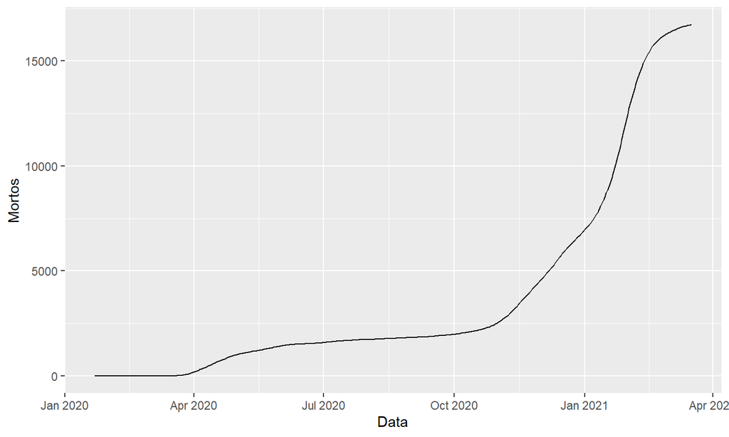

## COVID

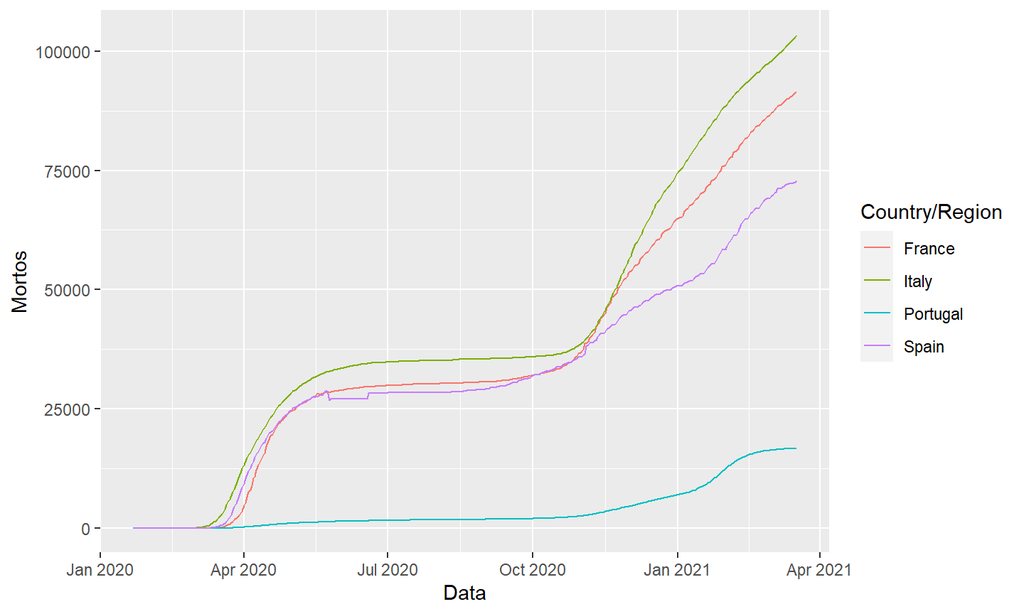

## COVID

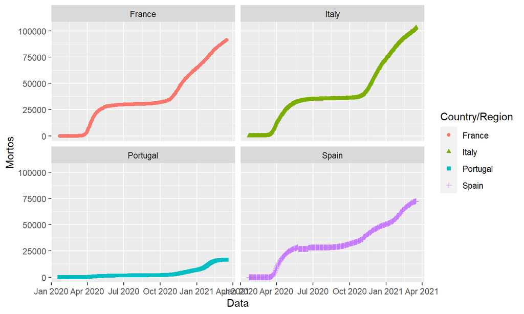

## Wisconsin Diagnostic Breast Cancer (WDBC)

- 32 campos
- id
- diagnosis
- 10 medidas com 3 valores:
  - mean
  - standard error
  - worst

## WDBC medidas

- radius (mean of distances from center to points on the perimeter)
- texture (standard deviation of gray-scale values)
- perimeter
- area
- smoothness (local variation in radius lengths)
- compactness (perimeter^2 / area - 1.0)
- concavity (severity of concave portions of the contour)
- concave points (number of concave portions of the contour)
- symmetry
- fractal dimension (“coastline approximation” - 1)

## WDBC

```r
url = "https://archive.ics.uci.edu/ml/machine-learning-databases/breast-cancer-wisconsin/wdbc.data"
flds = strsplit("radius texture perimeter area smoothness compactness
  concavity conv_pts symmetry fract_dim", "\\s+") %>% unlist
wdbc = read_csv(url) %>% set_names(c("id", "diagnosis",
  paste0(flds, "_mean"), paste0(flds, "_se"), paste0(flds, "_worst")))
wdbc %>% head
```

```
# A tibble: 6 x 32
        id diagnosis radius_mean texture_mean perimeter_mean area_mean
     <dbl> <chr>           <dbl>        <dbl>          <dbl>     <dbl>
1   842517 M                20.6         17.8          133.      1326
2 84300903 M                19.7         21.2          130       1203
3 84348301 M                11.4         20.4           77.6      386.
4 84358402 M                20.3         14.3          135.      1297
5   843786 M                12.4         15.7           82.6      477.
6   844359 M                18.2         20.0          120.      1040
# ... with 26 more variables: smoothness_mean <dbl>, compactness_mean <dbl>,
#   concavity_mean <dbl>, conv_pts_mean <dbl>, symmetry_mean <dbl>,
#   fract_dim_mean <dbl>, radius_se <dbl>, texture_se <dbl>,
#   perimeter_se <dbl>, area_se <dbl>, smoothness_se <dbl>,
#   compactness_se <dbl>, concavity_se <dbl>, conv_pts_se <dbl>,
#   symmetry_se <dbl>, fract_dim_se <dbl>, radius_worst <dbl>,
#   texture_worst <dbl>, perimeter_worst <dbl>, area_worst <dbl>,
#   smoothness_worst <dbl>, compactness_worst <dbl>, concavity_worst <dbl>,
#   conv_pts_worst <dbl>, symmetry_worst <dbl>, fract_dim_worst <dbl>
```

## WDBC PCA

```r
wdbc_pca = wdbc %>% nest(data=everything()) %>%
  mutate(pca = map(data, ~ prcomp(.x %>% select(-id, -diagnosis),
                                  center = TRUE, scale = TRUE)),
         pca_aug = map2(pca, data, ~augment(.x, data = .y)))
wdbc_pca
```

```
# A tibble: 1 x 3
  data                pca      pca_aug
  <list>              <list>   <list>
1 <tibble [568 x 32]> <prcomp> <tibble [568 x 63]>
```

## WDBC PCA

```r
var_exp = wdbc_pca %>% unnest(pca_aug) %>% summarize(across(matches("PC\\d+"), var)) %>%
  gather(key = pc, value = variance) %>%
  mutate(var_exp = variance/sum(variance),
         cum_var_exp = cumsum(var_exp),
         pc = str_replace(pc, ".fitted", ""))
var_exp
```

```
# A tibble: 30 x 4
   pc    variance var_exp cum_var_exp
   <chr>    <dbl>   <dbl>       <dbl>
 1 PC1     13.2    0.441        0.441
 2 PC2      5.72   0.191        0.632
 3 PC3      2.83   0.0944       0.726
 4 PC4      1.97   0.0656       0.792
 5 PC5      1.65   0.0551       0.847
 6 PC6      1.21   0.0404       0.887
 7 PC7      0.671  0.0224       0.910
 8 PC8      0.478  0.0159       0.926
 9 PC9      0.419  0.0140       0.940
10 PC10     0.351  0.0117       0.951
# ... with 20 more rows
```

## PCA

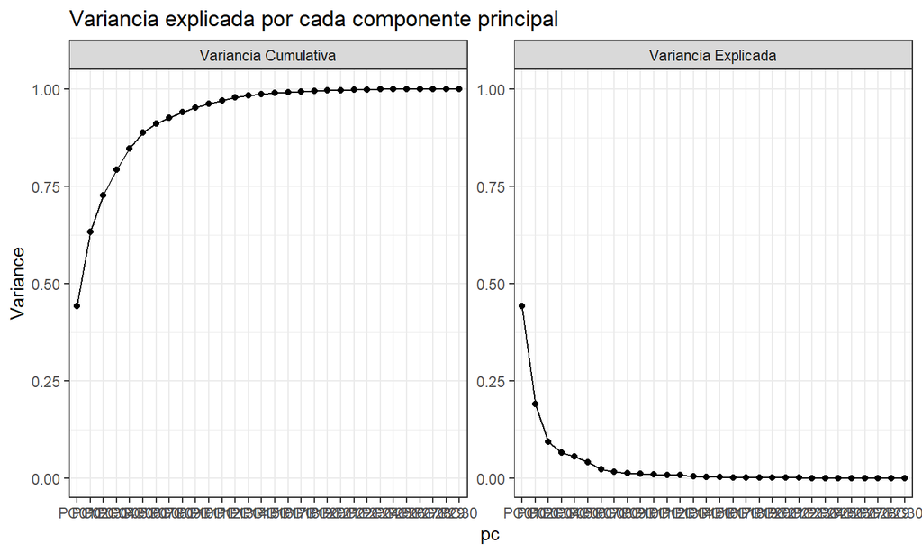

## PCA

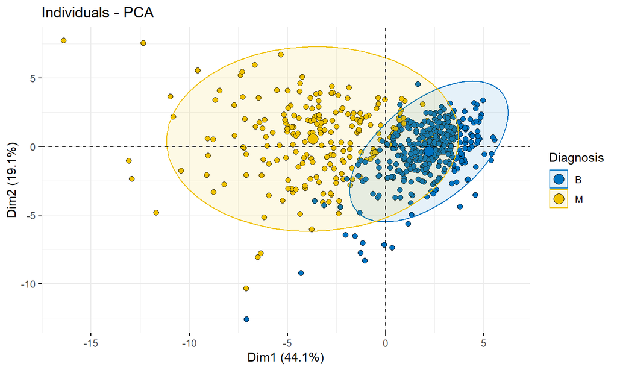

## Wine Quality

```r
wine_url = "https://archive.ics.uci.edu/ml/machine-learning-databases/wine-quality/winequality-white.csv"
wine = read_delim(wine_url, delim=";")
wine %>% summary
```

```
 fixed acidity    volatile acidity  citric acid     residual sugar
 Min.   : 3.800   Min.   :0.0800   Min.   :0.0000   Min.   : 0.600
 1st Qu.: 6.300   1st Qu.:0.2100   1st Qu.:0.2700   1st Qu.: 1.700
 Median : 6.800   Median :0.2600   Median :0.3200   Median : 5.200
 Mean   : 6.855   Mean   :0.2782   Mean   :0.3342   Mean   : 6.391
 3rd Qu.: 7.300   3rd Qu.:0.3200   3rd Qu.:0.3900   3rd Qu.: 9.900
 Max.   :14.200   Max.   :1.1000   Max.   :1.6600   Max.   :65.800
   chlorides       free sulfur dioxide total sulfur dioxide    density
 Min.   :0.00900   Min.   :  2.00      Min.   :  9.0        Min.   :0.9871
 1st Qu.:0.03600   1st Qu.: 23.00      1st Qu.:108.0        1st Qu.:0.9917
 Median :0.04300   Median : 34.00      Median :134.0        Median :0.9937
 Mean   :0.04577   Mean   : 35.31      Mean   :138.4        Mean   :0.9940
 3rd Qu.:0.05000   3rd Qu.: 46.00      3rd Qu.:167.0        3rd Qu.:0.9961
 Max.   :0.34600   Max.   :289.00      Max.   :440.0        Max.   :1.0390
       pH          sulphates         alcohol         quality
 Min.   :2.720   Min.   :0.2200   Min.   : 8.00   Min.   :3.000
 1st Qu.:3.090   1st Qu.:0.4100   1st Qu.: 9.50   1st Qu.:5.000
 Median :3.180   Median :0.4700   Median :10.40   Median :6.000
 Mean   :3.188   Mean   :0.4898   Mean   :10.51   Mean   :5.878
 3rd Qu.:3.280   3rd Qu.:0.5500   3rd Qu.:11.40   3rd Qu.:6.000
 Max.   :3.820   Max.   :1.0800   Max.   :14.20   Max.   :9.000
```

## Wine Quality

```r
wine %>% pivot_longer(cols = everything()) %>%
  group_by(name) %>% summarise_all(lst(min, mean, median, max))
```

```
# A tibble: 12 x 5
   name                   min     mean  median     max
 * <chr>                <dbl>    <dbl>   <dbl>   <dbl>
 1 alcohol              8      10.5     10.4    14.2
 2 chlorides            0.009   0.0458   0.043   0.346
 3 citric acid          0       0.334    0.32    1.66
 4 density              0.987   0.994    0.994   1.04
 5 fixed acidity        3.8     6.85     6.8    14.2
 6 free sulfur dioxide  2      35.3     34     289
 7 pH                   2.72    3.19     3.18    3.82
 8 quality              3       5.88     6       9
 9 residual sugar       0.6     6.39     5.2    65.8
10 sulphates            0.22    0.490    0.47    1.08
11 total sulfur dioxide 9     138.     134     440
12 volatile acidity     0.08    0.278    0.26    1.1
```

## Bibliografia

- [R for Data Science](https://r4ds.had.co.nz/index.html)